# Membresias MA

## Generales de los datos

| year | usuarios | Tiempo de membresia (avg) |
| --- | --- | --- |
| 2017 | 37 | 3 |
| 2018 | 31 | 3 |
| 2019 | 87 | 4 |
| 2020 | 137 | 3 |
| 2021 | 72 | 3 |
| 2022 | 39 | 2 |

- 2020 muestra el efecto pandémico positivo en el consumo y adopción de soluciones digitales en educación [^1] , así como su tasa a la baja al regresar opciones presenciales
- El tiempo promedio de la suscripciones es de **3 meses**

## Descripción de temporalidad de los usuarios

El gráfico muestra la cantidad porcentual (*A*) y acumulada (*B*) de los usuarios según su mes de compra, se desprende que :

- En el periodo comprendido entre febrero y mayo se concentra el 50 % de los usuarios documentados.
- Existe una baja sostenida de membresias desde julio a noviembre

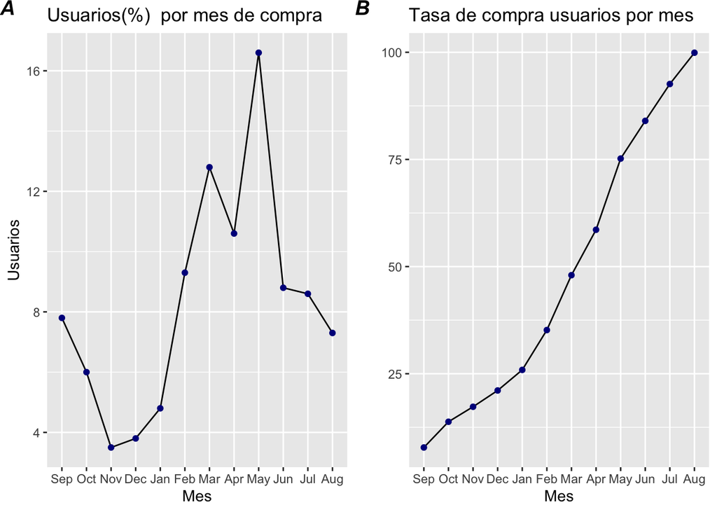

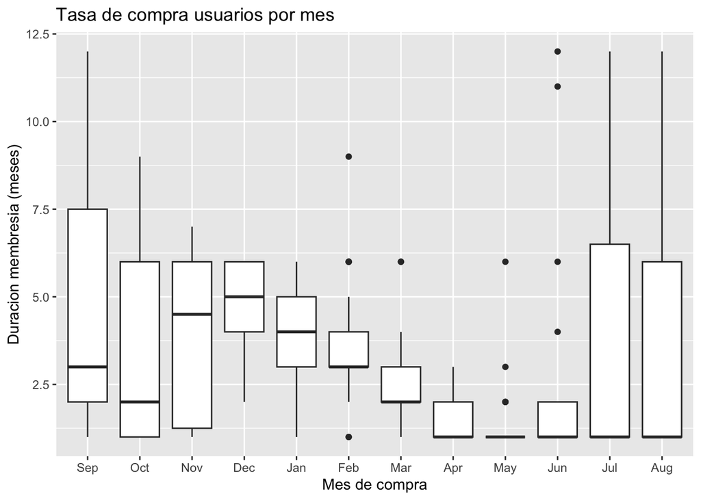

## Hábitos de consumo

Los gráficos muestran la distribución del consumo de cápsulas por los usuarios del conjunto de datos

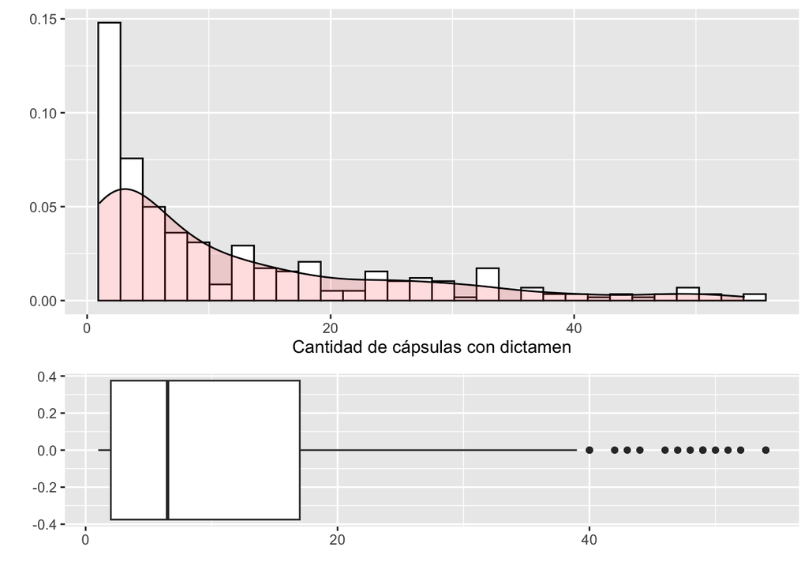

Se observa que:

- En promedio los usuarios terminaron 12 cápsulas
- El 25 % terminó más de 17 cápsulas

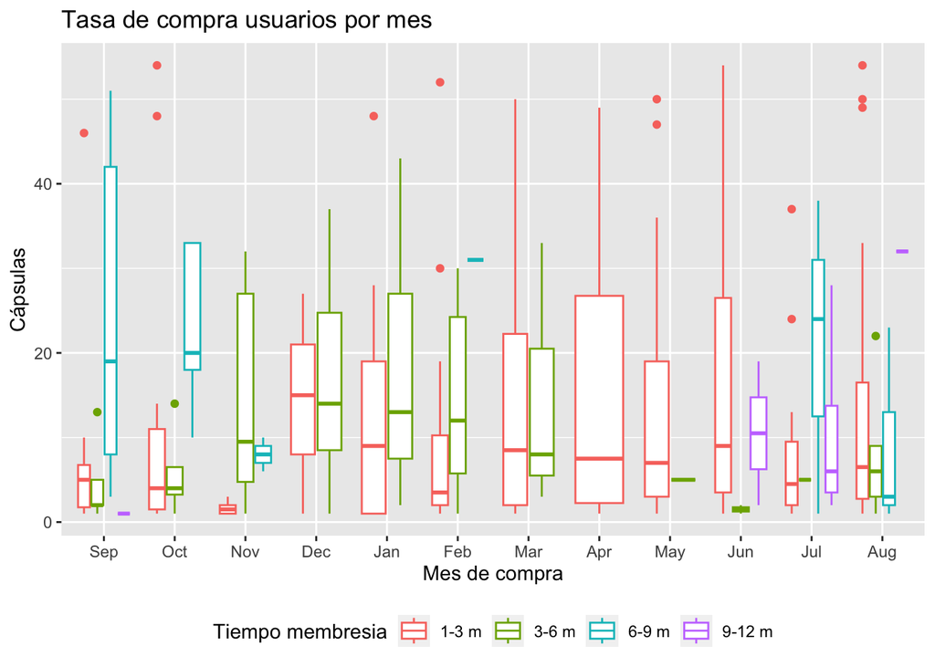

### Aprovechamiento

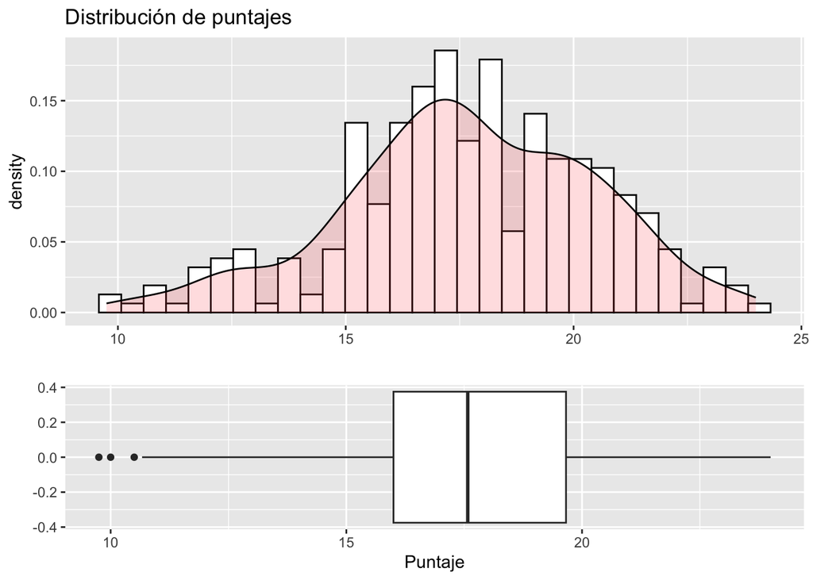

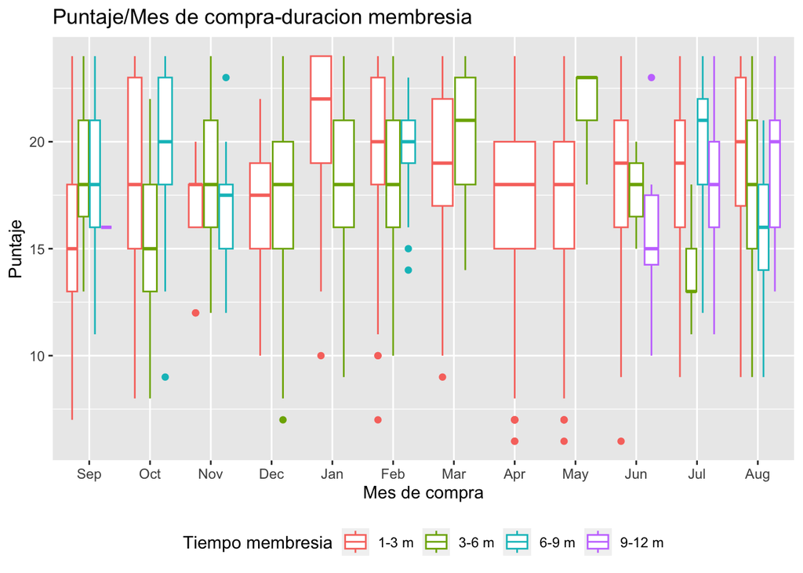

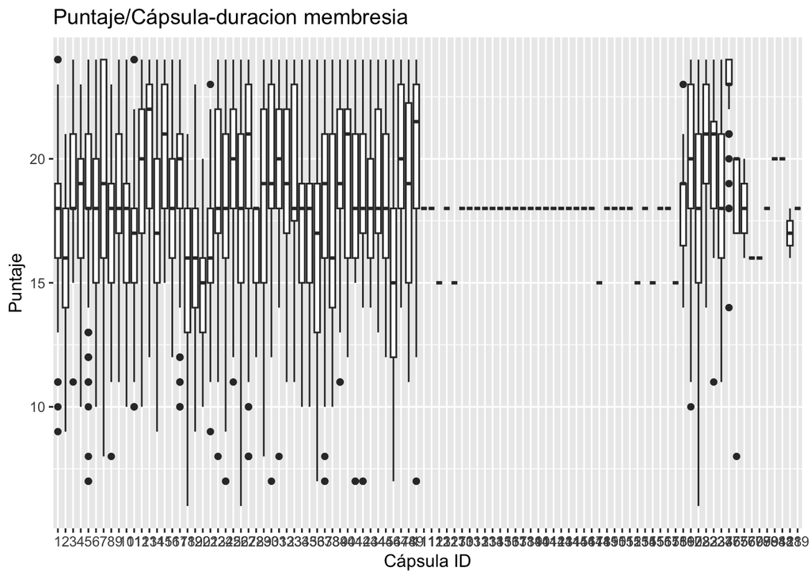

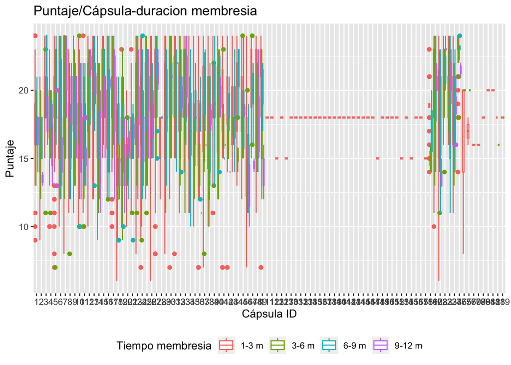

## Hábitos de consumo por cápsula

**Top cápsulas consumo**

| capsula_aprendizaje_id | n students | avg cal | % acierto |
| --- | --- | --- | --- |
| 23 | 206 | 19.05229 | 0.8794055 |
| 9 | 155 | 18.64479 | 0.8707606 |
| 24 | 136 | 17.90104 | NaN |
| 160 | 133 | 19.96985 | 0.9093769 |
| 10 | 124 | 17.40909 | 0.8318939 |
| 25 | 123 | 19.34831 | 0.9418468 |
| 26 | 112 | 18.35185 | 0.8906219 |
| 27 | 112 | 20.19394 | 0.9422668 |
| 5 | 111 | 18.66250 | 0.8735953 |
| 12 | 105 | 19.34194 | 0.9042903 |

[output cut: 5 more lines]

**Top cápsulas consumo asc()**

| capsula_aprendizaje_id | n students | avg cal |
| --- | --- | --- |
| 111 | 1 | 18 |
| 112 | 1 | 18 |
| 113 | 1 | 15 |
| 122 | 1 | 18 |
| 127 | 1 | 15 |
| 131 | 1 | 18 |
| 132 | 1 | 18 |
| 133 | 1 | 18 |
| 134 | 1 | 18 |
| 136 | 1 | 18 |

## Ideas sueltas

- Obtener una fecha estimada de cuando el usuario presente el examen, puede pedirsela para enviarle una alerta periodica (feature)
- Tasa de recompra
- Income por modalidad
[^1]: COLMAN, Helen. ¿ Cómo la pandemia por COVID-19 cambió la industria de la educación para siempre. Instituto Para El Futuro de La Educación, 2021.